# Self-Driving Car Engineer Nanodegree

## Project: Build a Traffic Sign Recognition Classifier

In this notebook, a template is provided for you to implement your functionality in stages, which is required to successfully complete this project. If additional code is required that cannot be included in the notebook, be sure that the Python code is successfully imported and included in your submission if necessary.

In addition to implementing code, there is a writeup to complete. The writeup should be completed in a separate file, which can be either a markdown file or a pdf document. There is a [write up template](https://github.com/udacity/CarND-Traffic-Sign-Classifier-Project/blob/master/writeup_template.md) that can be used to guide the writing process. Completing the code template and writeup template will cover all of the [rubric points](https://review.udacity.com/#!/rubrics/481/view) for this project.

The [rubric](https://review.udacity.com/#!/rubrics/481/view) contains "Stand Out Suggestions" for enhancing the project beyond the minimum requirements. The stand out suggestions are optional. If you decide to pursue the "stand out suggestions", you can include the code in this Ipython notebook and also discuss the results in the writeup file.

> **Note:** Code and Markdown cells can be executed using the **Shift + Enter** keyboard shortcut. In addition, Markdown cells can be edited by typically double-clicking the cell to enter edit mode.

## Step 0: Load The Data

```python
# Load pickled data
import pickle
import numpy as np
import tensorflow as tf
import matplotlib.pyplot as plt
from IPython.display import Image
import pandas as pd
from matplotlib import gridspec

%matplotlib inline

# TODO: Fill this in based on where you saved the training and testing data

training_file = './data/train.p'
testing_file = './data/test.p'

with open(training_file, mode='rb') as f:
    train = pickle.load(f)
with open(testing_file, mode='rb') as f:
    test = pickle.load(f)

X_train, y_train = train['features'], train['labels']
X_test, y_test = test['features'], test['labels']
```

## Step 1: Dataset Summary & Exploration

The pickled data is a dictionary with 4 key/value pairs:

- `'features'` is a 4D array containing raw pixel data of the traffic sign images, (num examples, width, height, channels).
- `'labels'` is a 1D array containing the label/class id of the traffic sign. The file `signnames.csv` contains id -> name mappings for each id.
- `'sizes'` is a list containing tuples, (width, height) representing the original width and height the image.
- `'coords'` is a list containing tuples, (x1, y1, x2, y2) representing coordinates of a bounding box around the sign in the image. **THESE COORDINATES ASSUME THE ORIGINAL IMAGE. THE PICKLED DATA CONTAINS RESIZED VERSIONS (32 by 32) OF THESE IMAGES**

Complete the basic data summary below. Use python, numpy and/or pandas methods to calculate the data summary rather than hard coding the results. For example, the [pandas shape method](http://pandas.pydata.org/pandas-docs/stable/generated/pandas.DataFrame.shape.html) might be useful for calculating some of the summary results.

### Provide a Basic Summary of the Data Set Using Python, Numpy and/or Pandas

```python
### Replace each question mark with the appropriate value.
import numpy as np

# TODO: Number of training examples
n_train = len(X_train)

# TODO: Number of testing examples.
n_test = len(X_test)

# TODO: What's the shape of an traffic sign image?
image_shape = X_train.shape

# TODO: How many unique classes/labels there are in the dataset.
n_classes = len(np.unique(y_train))

print("Number of training examples =", n_train)
print("Number of testing examples =", n_test)
print("Image data shape =", image_shape)
print("Number of classes =", n_classes)

# constants
learning_rate = 0.001
reg_param = 1e-5
batch_size = 128
epochs = 100
dev_data_percentage = 0.1
```

```
Number of training examples = 34799
Number of testing examples = 12630
Image data shape = (34799, 32, 32, 3)
Number of classes = 43
```

### Include an exploratory visualization of the dataset

Visualize the German Traffic Signs Dataset using the pickled file(s). This is open ended, suggestions include: plotting traffic sign images, plotting the count of each sign, etc.

The [Matplotlib](http://matplotlib.org/) [examples](http://matplotlib.org/examples/index.html) and [gallery](http://matplotlib.org/gallery.html) pages are a great resource for doing visualizations in Python.

**NOTE:** It's recommended you start with something simple first. If you wish to do more, come back to it after you've completed the rest of the sections. It can be interesting to look at the distribution of classes in the training, validation and test set. Is the distribution the same? Are there more examples of some classes than others?

```
Sample images
```

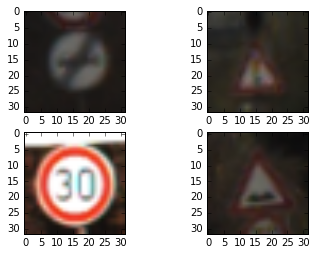

```python
# sample images
print('Sample images')
for i in range(4):
    plt.subplot(2,2,i+1)
    plt.imshow(X_train[i*1500+1])
```

```
[]
```

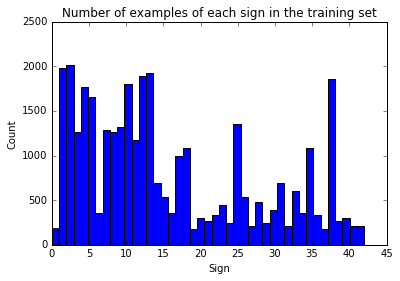

```python
# Plot a histogram of the count of the number of examples of each sign
# in the test set
plt.hist(y_train, bins=n_classes)
plt.title('Number of examples of each sign in the training set')
plt.xlabel('Sign')
plt.ylabel('Count')
plt.plot()
```

## Step 2: Design and Test a Model Architecture

Design and implement a deep learning model that learns to recognize traffic signs. Train and test your model on the [German Traffic Sign Dataset](http://benchmark.ini.rub.de/?section=gtsrb&subsection=dataset).

The LeNet-5 implementation shown in the classroom at the end of the CNN lesson is a solid starting point. You'll have to change the number of classes and possibly the preprocessing, but aside from that it's plug and play!

With the LeNet-5 solution from the lecture, you should expect a validation set accuracy of about 0.89. To meet specifications, the validation set accuracy will need to be at least 0.93. It is possible to get an even higher accuracy, but 0.93 is the minimum for a successful project submission.

There are various aspects to consider when thinking about this problem:

- Neural network architecture (is the network over or underfitting?)
- Play around preprocessing techniques (normalization, rgb to grayscale, etc)
- Number of examples per label (some have more than others).
- Generate fake data.

Here is an example of a [published baseline model on this problem](http://yann.lecun.com/exdb/publis/pdf/sermanet-ijcnn-11.pdf). It's not required to be familiar with the approach used in the paper but, it's good practice to try to read papers like these.

### Pre-process the Data Set (normalization, grayscale, etc.)

Minimally, the image data should be normalized so that the data has mean zero and equal variance. For image data, `(pixel - 128)/ 128` is a quick way to approximately normalize the data and can be used in this project.

Other pre-processing steps are optional. You can try different techniques to see if it improves performance.

Use the code cell (or multiple code cells, if necessary) to implement the first step of your project.

```python
### Preprocess the data here.It is required to normalize the data. Other preprocessing steps could include
### converting to grayscale, etc.
### Feel free to use as many code cells as needed.
import impfunctions
# Step: 1 Min-Max Normalization
X_train_maxmin = impfunctions.min_max_normalization(X_train)
X_test_maxmin = impfunctions.min_max_normalization(X_test)

# Step: 2 One-Hot-Encoding
y_train, y_test = impfunctions.one_hot_encoding(y_train, y_test)

# Step: 3 train and dev split
train_features, dev_features, train_labels, dev_labels = impfunctions.train_dev_split(
    X_train_maxmin, y_train, dev_data_percentage)

training_dataset = impfunctions.DataSet(train_features, train_labels)
dev_dataset = impfunctions.DataSet(dev_features, dev_labels)
testing_dataset = impfunctions.DataSet(X_test_maxmin, y_test)
```

### Model Architecture

```
Epoch:0 train loss:1.9067 dev loss:1.9502 train accu:0.4062 dev accu:0.3796
Epoch:20 train loss:0.0126 dev loss:0.0505 train accu:1.0000 dev accu:0.9896
Epoch:40 train loss:0.0065 dev loss:0.0415 train accu:1.0000 dev accu:0.9925
Epoch:60 train loss:0.0042 dev loss:0.0467 train accu:1.0000 dev accu:0.9945
Epoch:80 train loss:0.0048 dev loss:0.0378 train accu:1.0000 dev accu:0.9931
Trained model saved to the disk.
```

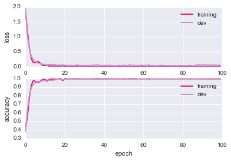

```python
### Define your architecture here.
### Feel free to use as many code cells as needed.

rate_learning = 1e-3
num_classes = 43
batch_size = 128
epochs = 100
reg_parameter = 1e-6
TRAINING_FILE = './data/train.p'
TESTING_FILE = './data/test.p'
model_arch = './checkpoint_lenetplus/LeNetPlus.ckpt'

def LeNetPlus(data):
    # 1st convolutional layer
    with tf.name_scope('conv_1'):
        first_conv_w = tf.Variable(tf.truncated_normal(shape=(5, 5, 3, 6), stddev = 0.01))
        first_conv_b = tf.Variable(tf.zeros(6))
        first_conv = tf.nn.second_convd(x, first_conv_w, strides=[1, 1, 1, 1], padding='VALID') + first_conv_b
        first_conv = tf.nn.relu(first_conv)
        first_conv = tf.nn.max_pool(first_conv, ksize=[1, 2, 2, 1], strides=[1, 2, 2, 1], padding='VALID')

    # 2nd Convolutional layer
    with tf.name_scope('conv_2'):
        second_conv_w = tf.Variable(tf.truncated_normal(shape=(5, 5, 6, 16), stddev = 0.01))
        second_conv_b = tf.Variable(tf.zeros(16))
        second_conv = tf.nn.second_convd(first_conv, second_conv_w, strides=[1, 1, 1, 1], padding='VALID') + second_conv_b
        second_conv = tf.nn.relu(second_conv)
        second_conv = tf.nn.max_pool(second_conv, ksize=[1, 2, 2, 1], strides=[1, 2, 2, 1], padding='VALID')

    # 1st fully-connected layer
    with tf.name_scope('fc_1'):
        fully_connected_layer_1 = flatten(second_conv)
        fully_connected_layer_1_shape = (fully_connected_layer_1.get_shape().as_list()[-1], 1024)
        fully_connected_layer_1_w = tf.Variable(tf.truncated_normal(shape=(fully_connected_layer_1_shape), stddev = 0.01))
        fully_connected_layer_1_b = tf.Variable(tf.zeros(1024))
        fully_connected_layer_1 = tf.matmul(fully_connected_layer_1, fully_connected_layer_1_w) + fully_connected_layer_1_b
        fully_connected_layer_1 = tf.nn.relu(fully_connected_layer_1)
        fully_connected_layer_1 = tf.nn.dropout(fully_connected_layer_1, keep_prob)

    # 2nd fully-connected layer
    with tf.name_scope('fc_2'):
        fully_connected_layer_w = tf.Variable(tf.truncated_normal(shape=(1024, 1024), stddev=0.01))
        fully_connected_layer_b = tf.Variable(tf.zeros(1024))
        fully_connected_layer = tf.matmul(fully_connected_layer_1, fully_connected_layer_w) + fully_connected_layer_b
        fully_connected_layer = tf.nn.relu(fully_connected_layer)
        fully_connected_layer = tf.nn.dropout(fully_connected_layer, keep_prob)

    with tf.name_scope('logit'):
        logit_w = tf.Variable(tf.truncated_normal(shape=(1024, num_classes), stddev = 0.01))
        logit_b = tf.Variable(tf.zeros(num_classes))
        return (tf.matmul(fully_connected_layer, logit_w) + logit_b), [first_conv_w, second_conv_w, fully_connected_layer_1_w, fully_connected_layer_w, logit_w]

def regularization_cost(weights, regularization):
    reg_cost = 0.0
    for weight in weights:
        reg_cost += regularization * tf.nn.l2_loss(weight)
    return reg_cost
#placeholders
x = tf.placeholder("float", [None, 32, 32, 3])
tf.add_to_collection("x", x)
y = tf.placeholder("float", [None, num_classes])
tf.add_to_collection("y", y)

keep_prob = tf.placeholder(tf.float32)
tf.add_to_collection("keep_prob", keep_prob)

logits, weights = LeNetPlus(x)
tf.add_to_collection("logits", logits)

loss_op = tf.reduce_mean(tf.nn.softmax_cross_entropy_with_logits(logits, y)) + \
          regularization_cost(weights, reg_parameter)
tf.add_to_collection('loss_op', loss_op)

optimizer = tf.train.AdamOptimizer(rate_learning)
train_op = optimizer.minimize(loss_op)

correct_prediction = tf.equal(tf.argmax(logits, 1), tf.argmax(y, 1))
accuracy_op = tf.reduce_mean(tf.cast(correct_prediction, tf.float32))
tf.add_to_collection('accuracy_op', accuracy_op)

def eval_data(dataset):
    steps_per_epoch = dataset.length() // batch_size
    num_examples = steps_per_epoch * batch_size
    total_acc, total_loss = 0, 0
    for step in range(steps_per_epoch):
        batch_x, batch_y = dataset.next_batch(batch_size)
        loss, acc = sess.run([loss_op, accuracy_op],
                             feed_dict={x: batch_x, y: batch_y, keep_prob: 1.0})
        total_acc += (acc * batch_x.shape[0])
        total_loss += (loss * batch_x.shape[0])
    return total_loss / num_examples, total_acc / num_examples

saver = tf.train.Saver()
best_dev_acc = 1e-10

with tf.Session() as sess:
    sess.run(tf.global_variables_initializer())
    steps_per_epoch = len(train_features) // batch_size
    num_examples = steps_per_epoch * batch_size

    training_accuracies = []
    dev_accuracies = []

    training_losses = []
    dev_losses = []

    for epoch in range(epochs):

        for step in range(steps_per_epoch):
            batch_x, batch_y = training_dataset.next_batch(batch_size)
            loss, accur = sess.run([train_op, accuracy_op],
                                   feed_dict={x: batch_x, y: batch_y, keep_prob: 0.5})

        # training loss and accuracy after an epoch
        loss_tr, acc_tr = sess.run([loss_op, accuracy_op],
                                   feed_dict={x: batch_x, y: batch_y, keep_prob: 1.0})
        training_losses.append(loss_tr)
        training_accuracies.append(acc_tr)

        loss_dev, acc_dev = eval_data(dev_dataset)
        dev_accuracies.append(acc_dev)
        dev_losses.append(loss_dev)

        if acc_dev > best_dev_acc:
                saver.save(sess, model_arch, global_step=step)
                best_dev_acc = acc_dev

        if epoch % 20 == 0:
            print('Epoch:{:d} train loss:{:.4f} dev loss:{:.4f} train accu:{:.4f} dev accu:{:.4f}'.format(
                    epoch, loss_tr, loss_dev, acc_tr, acc_dev))

    print('Trained model saved to the disk.')
    impfunctions.plot_learning_curves(training_losses, training_accuracies, dev_losses, dev_accuracies)
```

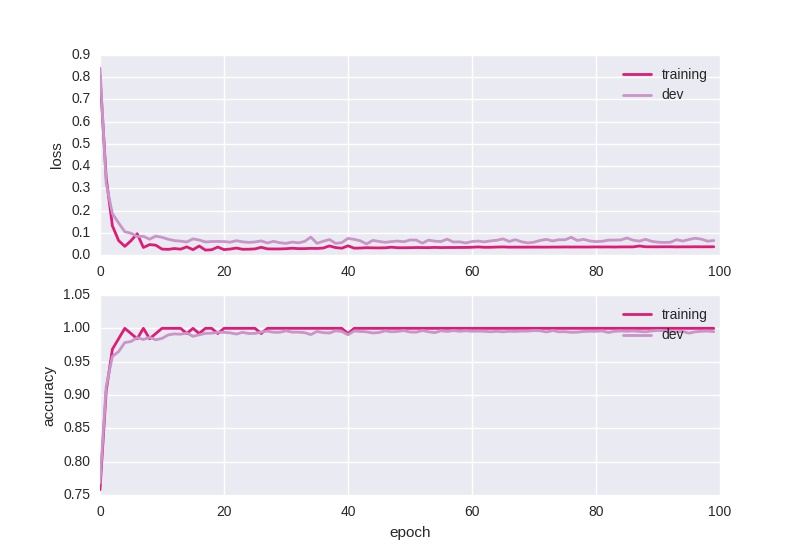

```python
Image('./images/learning_curves_1024_512_fully_connected.jpg')
```

[figure not shown]

```python
def display_augmented_images(image_dataset, augmented_data, n_rows):
    '''
    function for displaying augmented images.
    '''
    plt.figure(figsize=(5,7.5))
    selected_classes = np.random.randint(0, 44, size=n_rows)
    image_number = 1
    for row in selected_classes:
        x_selected = X_train[np.argmax(y_train, axis=1) == row]
        index = 0 # first image of each image category

        plt.subplot(n_rows, 2, image_number)
        plt.imshow(x_selected[index, :, :, :])
        plt.axis('off')
        plt.title('class: {}'.format(row))
        image_number += 1

        aug_selected = augmented_data[np.argmax(y_train, axis=1) == row]

        plt.subplot(n_rows, 2, image_number)
        plt.imshow(aug_selected[index, :, :, :])
        plt.axis('off')
        plt.title('class: {}'.format(row))
        image_number += 1

    plt.suptitle('Original Image (First Column) and Augmented Image (Second Column)')
    plt.show()


X_train_transformed = np.zeros_like(X_train)
y_train_transformed = np.zeros_like(y_train)

for i in range(X_train_transformed.shape[0]): #
    X_train_transformed[i] = impfunctions.transform_image(X_train[i], 20, 10, 5)
    y_train_transformed[i] = y_train[i]

display_augmented_images(X_train, X_train_transformed, 5)
```

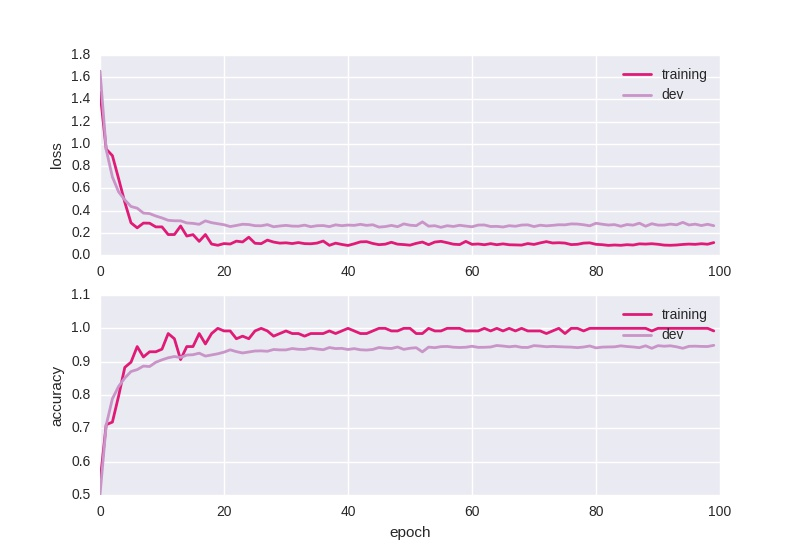

```python
Image('./images/learning_curves_with_augmented_data.jpg')
```

### Train, Validate and Test the Model

By considering all three graphs, I decided this model (6 and 16 convolution layer, 1024 and 1024 fully connected layers, running without augmented data) is the current best model. So I tested its performance using testing dataset is given below.

```python
with tf.Session(graph = tf.Graph()) as sess:
    saver = tf.train.import_meta_graph('./checkpoint_lenetplus/LeNetPlus.ckpt-274.meta')
    saver.restore(sess,  tf.train.latest_checkpoint('./checkpoint_lenetplus'))

    x = tf.get_collection("x")[0]
    y = tf.get_collection("y")[0]
    keep_prob = tf.get_collection("keep_prob")[0]
    logits = tf.get_collection('logits')[0]
    accuracy_op = tf.get_collection('accuracy_op')[0]
    loss_op = tf.get_collection('loss_op')[0]

    model_loss, model_perf = eval_data(testing_dataset)
    print('Test Dataset Classification Accuracy: {:.4f}'.format(model_perf))
```

```
Test Dataset Classification Accuracy: 0.9383
```

```python
### Train your model here.
### Feel free to use as many code cells as needed.

### Model training is done above
```

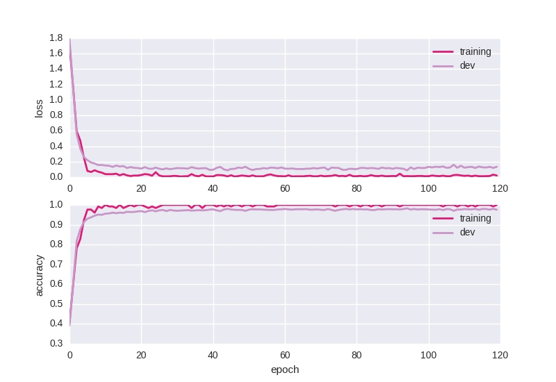

```python
Image('./images/learning_curves_64_64_128_1024_1024.jpg')
```

```python
with tf.Session(graph = tf.Graph()) as sess:
    saver = tf.train.import_meta_graph(
        './checkpoint_64_64_128_1024_1024/LeNetPlusPlus_64_64_128_1024_1024.ckpt-550.meta')
    saver.restore(sess,  tf.train.latest_checkpoint('./checkpoint_64_64_128_1024_1024'))

    # Retrieve the Ops we 'remembered'.
    x = tf.get_collection("x")[0]
    y = tf.get_collection("y")[0]
    keep_prob = tf.get_collection("keep_prob")[0]
    logit = tf.get_collection('logit')[0]
    accuracy_op = tf.get_collection('accuracy_op')[0]
    loss_op = tf.get_collection('loss_op')[0]

    model_loss, model_perf = eval_data(testing_dataset)
    print('Test Dataset Classification Accuracy: {:.4f}'.format(model_perf))
```

```
Test Dataset Classification Accuracy: 0.9662
```

## Step 3: Test a Model on New Images

Take several pictures of traffic signs that you find on the web or around you (at least five), and run them through your classifier on your computer to produce example results. The classifier might not recognize some local signs but it could prove interesting nonetheless.

You may find `signnames.csv` useful as it contains mappings from the class id (integer) to the actual sign name.

### Load and Output the Images

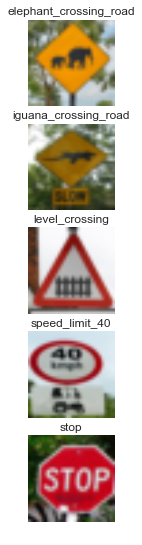

```python
### Load the images and plot them here.
### Feel free to use as many code cells as needed.

import os
import scipy.misc

NEW_IMAGES_FOLDER = './new_images/'

labels = {0: 'stop',
          1: 'elephant crossing road',
          2: 'level crossing',
          3: 'speed limit 40 km/h',
          4: 'iguana crossing road'}

def resize_image(image_file):
    image = plt.imread(NEW_IMAGES_FOLDER + image_file)
    return scipy.misc.imresize(image, (32, 32))

resized_image_data = [(resize_image(image), image[:-4])
                          for image in os.listdir(NEW_IMAGES_FOLDER)]

def display_images(imgs_data):
    index = 1
    plt.figure(figsize=(4,9))
    for img, name in imgs_data:
        plt.subplot(5, 1, index)
        plt.imshow(img)
        plt.axis('off')
        plt.title(name)
        index += 1
    plt.show()

display_images(resized_image_data)
```

### Analyze Performance

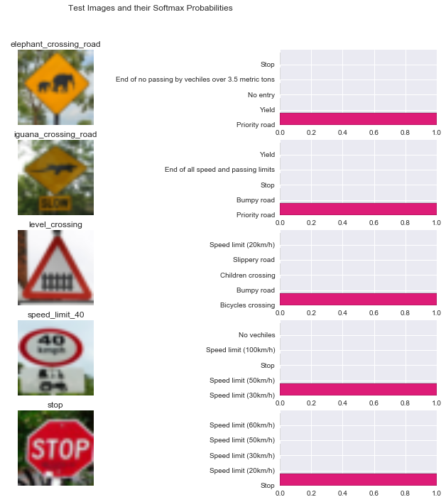

```python
### Run the predictions here.
### Feel free to use as many code cells as needed.

resized_images = [img_and_name[0] for img_and_name in resized_image_data]
X_test_new_dataset = impfunctions.min_max_normalization(np.array(resized_images))

def print_result(ground_truth, top_k_prob, top_k_indices):
    class_names = pd.read_csv('./data/signnames.csv')['SignName'].values
    index = 0
    img_index = 0
    plt.figure(figsize=(14, 11))
    gs = gridspec.GridSpec(5, 2, width_ratios=[1, 0.45])
    for key in ground_truth:
        img, tag = resized_image_data[img_index]
        img_index += 1
        plt.subplot(gs[index])
        plt.imshow(img)
        plt.axis('off')
        plt.title(tag)
        index += 1

        plt.subplot(gs[index])
        plt.barh(np.arange(1, 6, 1),
                 top_k_prob[key, :],
                 0.8,
                 color='#dd1c77')
        plt.yticks(np.arange(1, 6, 1), class_names[top_k_indices[key, :]])
        index += 1
    plt.suptitle('Test Images and their Softmax Probabilities')
    plt.show()



with tf.Session(graph = tf.Graph()) as sess:
    saver = tf.train.import_meta_graph(
        './checkpoint_64_64_128_1024_1024/LeNetPlusPlus_64_64_128_1024_1024.ckpt-550.meta')
    saver.restore(sess,  tf.train.latest_checkpoint('./checkpoint_64_64_128_1024_1024'))

    # Retrieve the Ops we 'remembered'.
    x = tf.get_collection("x")[0]
    y = tf.get_collection("y")[0]
    keep_prob = tf.get_collection("keep_prob")[0]
    logits = tf.get_collection('logit')[0]
    softmax = tf.nn.softmax(logits)
    normalized_prob = sess.run(softmax, feed_dict={x: X_test_new_dataset, keep_prob: 1.0})
    top_k_op = tf.nn.top_k(normalized_prob, k=5)
    top_k_results = sess.run(top_k_op)

    # show predictions with their probabilities
    print_result(labels, top_k_results.values, top_k_results.indices)
```

### Output Top 5 Softmax Probabilities For Each Image Found on the Web

For each of the new images, print out the model's softmax probabilities to show the **certainty** of the model's predictions (limit the output to the top 5 probabilities for each image). [`tf.nn.top_k`](https://www.tensorflow.org/versions/r0.12/api_docs/python/nn.html#top_k) could prove helpful here.

The example below demonstrates how tf.nn.top_k can be used to find the top k predictions for each image.

`tf.nn.top_k` will return the values and indices (class ids) of the top k predictions. So if k=3, for each sign, it'll return the 3 largest probabilities (out of a possible 43) and the correspoding class ids.

Take this numpy array as an example. The values in the array represent predictions. The array contains softmax probabilities for five candidate images with six possible classes. `tf.nn.top_k` is used to choose the three classes with the highest probability:

```
# (5, 6) array
a = np.array([[ 0.24879643,  0.07032244,  0.12641572,  0.34763842,  0.07893497,
         0.12789202],
       [ 0.28086119,  0.27569815,  0.08594638,  0.0178669 ,  0.18063401,
         0.15899337],
       [ 0.26076848,  0.23664738,  0.08020603,  0.07001922,  0.1134371 ,
         0.23892179],
       [ 0.11943333,  0.29198961,  0.02605103,  0.26234032,  0.1351348 ,
         0.16505091],
       [ 0.09561176,  0.34396535,  0.0643941 ,  0.16240774,  0.24206137,
         0.09155967]])
```

Running it through `sess.run(tf.nn.top_k(tf.constant(a), k=3))` produces:

```
TopKV2(values=array([[ 0.34763842,  0.24879643,  0.12789202],
       [ 0.28086119,  0.27569815,  0.18063401],
       [ 0.26076848,  0.23892179,  0.23664738],
       [ 0.29198961,  0.26234032,  0.16505091],
       [ 0.34396535,  0.24206137,  0.16240774]]), indices=array([[3, 0, 5],
       [0, 1, 4],
       [0, 5, 1],
       [1, 3, 5],
       [1, 4, 3]], dtype=int32))
```

Looking just at the first row we get `[ 0.34763842, 0.24879643, 0.12789202]`, you can confirm these are the 3 largest probabilities in `a`. You'll also notice `[3, 0, 5]` are the corresponding indices.

*Note: the comparision was done under analyze performance tab*